# ICE Annina 10x sequencing analysis - Comparison analysis of human and organoid datasets

Author

Vladyslav Korobeynyk at Jessberger/Robinsonlab, UZH

Published

October 5, 2026

**Note**

**What this script does:** brings together the human and organoid glmnet models and DEA results generated by the earlier scripts, to test whether they capture shared biology. It compares (1) which genes are selected as predictive by both the human age-regression and organoid phenotype-classification models (Venn diagrams), (2) whether log2 fold changes agree in direction between the human Age DEA and the organoid mCh-vs-wt DEA (concordance scatter), (3) which GO terms are commonly enriched across organoid celltypes, and (4) a combined “circular” view of coefficients and fold changes across both datasets for the top genes by each metric.

**Important**

Two of the sections below (**“Most enriched overall GOterms”** and the **organoid side of “Genes correlated log2FC”/“Circular fan plot”**) depend on output files that, as of the current pipeline, are not produced anywhere:

- `gsea_perCelltype_10w.txt` / `gsea_perCelltype_4m.txt` - `03_organoid_Analysis_singleCell_Level.qmd` currently saves this data as an RDS **list** (`gsea_perCelltype_10w_lst.RDS` / `_4m_lst.RDS`), not a flat `.txt` table with `Celltype`/`cluster`/`NES`/`score`/ `parentTerm` columns. Either there’s a manual flattening step done outside the tracked scripts, or this section is currently reading a stale/missing file.
- `DEA_pseudobulk_mCh_vs_wt_iN_All_datasets.csv` / `..._exN_All_datasets.csv` - no current script saves a **per-celltype** (IN and EN separately), all-organoid-datasets-pooled DEA table. `02_organoid_Analysis_metacell_Level.qmd`’s closest equivalent (“DEA | neurons + all datasets together”) pools IN and EN *together* (with Celltype as a covariate) and doesn’t write its result to disk at all.

Both are preserved below with their original (unresolved) paths, flagged inline, so this renders identically to before pending your input on how to regenerate them.

# Setup

```r
suppressMessages({
  library(dplyr)
  library(Seurat)
  library(magrittr)
  library(rrvgo)
  library(ggplot2)
  library(ggVennDiagram)
  library(genekitr)
  library(geneset)
  library(ggrepel)
  library(DT)
  library(ggnewscale)
})
source(params$helper_functions_path)

dir.create(params$publication_plots_dir, recursive = TRUE, showWarnings = FALSE)

N_nonZeroCoefs = params$n_nonzero_coefs_threshold
```

# Helper functions for this script

```r
#' Filter glmnet coefficient tables (one column per seed, plus a 'mean' column) to genes
#' selected in more than `threshold` seeds, and plot a Venn diagram of the overlap
#' between the human and organoid selected-gene sets
venn_common_glmnet_genes = function(human_coefs_path, organoid_coefs_path, threshold, title_label) {
  human_coefs = read.table(human_coefs_path)
  human_coefs = human_coefs[rowSums(human_coefs[, seq_len(ncol(human_coefs) - 1)] != 0) >= threshold, ]

  organoid_coefs = read.table(organoid_coefs_path)
  organoid_coefs = organoid_coefs[rowSums(organoid_coefs[, seq_len(ncol(organoid_coefs) - 1)] != 0) >= threshold, ]

  rownames(organoid_coefs) = organoid_coefs$gene

  print(
    ggVennDiagram(list(human = rownames(human_coefs), organoid = rownames(organoid_coefs)), label_alpha = 0) +
      scale_fill_distiller(palette = "RdBu") +
      ggtitle(title_label)
  )

  intersect(rownames(human_coefs), rownames(organoid_coefs))
}

#' Compare log2FC between a human and an organoid DEA table: Venn diagrams of the
#' up/down-regulated gene overlap, plus a concordance scatter highlighting genes that
#' were also selected (non-zero coefficient) by both glmnet models
plot_log2fc_concordance = function(human_dea_path, organoid_dea_path, common_glmnet_genes, celltype_label,
                                    restrict_to_significant = TRUE) {
  markers_human = read.csv(human_dea_path) %>% na.omit()
  markers_human$significant = markers_human$padj < 0.05
  # Rescale ghuman per-year log2fc
  markers_human$avg_log2FC = markers_human$avg_log2FC * (79-31) # max - min of patients age tested

  markers_org = read.csv(organoid_dea_path) %>% na.omit()
  markers_org$significant = markers_org$padj < 0.05

  print(
    ggVennDiagram(list(human = markers_human %>% filter(avg_log2FC < 0) %>% pull(gene),
                        organoid = markers_org %>% filter(avg_log2FC < 0) %>% pull(gene)), label_alpha = 0) +
      scale_fill_distiller(palette = "RdBu") +
      ggtitle(paste0("Markers with Log2FC < 0 - ", celltype_label))
  )
  print(
    ggVennDiagram(list(human = markers_human %>% filter(avg_log2FC > 0) %>% pull(gene),
                        organoid = markers_org %>% filter(avg_log2FC > 0) %>% pull(gene)), label_alpha = 0) +
      scale_fill_distiller(palette = "RdBu") +
      ggtitle(paste0("Markers with Log2FC > 0 - ", celltype_label))
  )

  merged = full_join(markers_human, markers_org, by = "gene", suffix = c("_human", "_org")) %>% na.omit()
  merged$avg_log2FC_human[is.na(merged$avg_log2FC_human)] = 0
  merged$avg_log2FC_org[is.na(merged$avg_log2FC_org)] = 0
  merged$glmnet_genes = merged$gene %in% common_glmnet_genes

  # Restrict the correlation/plot to genes with real signal in at least one dataset -
  # genes non-significant in both are mostly noise near (0,0) and dilute any real trend
  plot_df = if (restrict_to_significant) {
    merged %>% filter(significant_human | significant_org)
  } else {
    merged
  }

  # Direction concordance: of genes changing in the same direction in both, what
  # fraction agree vs. disagree? A simple, robust companion to the correlation stat.
  concordant = sum(sign(plot_df$avg_log2FC_human) == sign(plot_df$avg_log2FC_org))
  pct_concordant = round(100 * concordant / nrow(plot_df), 1)

  p = ggplot(plot_df, aes(x = avg_log2FC_human, y = avg_log2FC_org)) +
    geom_point(aes(color = glmnet_genes, size = glmnet_genes)) +
    scale_color_manual(values = c("TRUE" = "firebrick", "FALSE" = "gray70")) +
    scale_size_manual(values = c("TRUE" = 5, "FALSE" = 1)) +
    geom_smooth(method = "lm", color = "black", linetype = "dashed", se = TRUE, inherit.aes = FALSE,
                aes(x = avg_log2FC_human, y = avg_log2FC_org)) +
    ggpubr::stat_cor(
      method = "spearman",
      aes(x = avg_log2FC_human, y = avg_log2FC_org, label = ..rr.label..),
      inherit.aes = FALSE,
      label.x.npc = "left", label.y.npc = "top"
      ) +
    geom_text_repel(
      data = subset(plot_df, glmnet_genes),
      aes(label = gene), size = 5, color = "black",
      nudge_y = 1, segment.color = "gray30", segment.size = 0.4
    ) +
    geom_hline(yintercept = 0) +
    geom_vline(xintercept = 0) +
    labs(
      x = "log2FC human", y = "log2FC organoid",
      title = paste0("Comparison of log2 Fold Changes - ", celltype_label,
                      " | highlighted genes had non-zero coefficients in both human and organoid models"),
      subtitle = paste0(pct_concordant, "% of shown genes (n=", nrow(plot_df),
                         ") change in the same direction in both datasets",
                         if (restrict_to_significant) " (restricted to genes significant in at least one dataset)" else "")
    )

  print(p)

  merged
}

#' Summarize which reduced GO parent terms recur across more than one celltype, for one
#' NES direction (NES > 0 = enriched toward mCh, NES < 0 = enriched toward wt)
summarize_common_goterms_direction = function(goterms, nes_positive, maturation_label) {
  filtered = if (nes_positive) goterms %>% filter(NES > 0) else goterms %>% filter(NES < 0)

  # keep each celltype/cluster's single best (highest-score) term
  filtered = filtered %>%
    group_by(Celltype, cluster) %>%
    slice_max(order_by = score, n = 1) %>%
    ungroup()

  direction_label = if (nes_positive) "NES > 0" else "NES < 0"

  term_counts = filtered %>%
    filter(go != 0) %>%
    dplyr::count(parentTerm, sort = TRUE) %>%
    filter(n > 1) %>%
    set_colnames(c(paste0("Common GOterms across celltypes - CO ", maturation_label, " ", direction_label), "N"))

  knitr::kable(term_counts)
}

summarize_common_goterms = function(goterms_path, maturation_label) {
  goterms = read.table(goterms_path) %>% na.omit()
  print(summarize_common_goterms_direction(goterms, nes_positive = TRUE, maturation_label))
  print(summarize_common_goterms_direction(goterms, nes_positive = FALSE, maturation_label))
}

#' Build the 4-track comparison plot (human coefficient, organoid coefficient, human
#' log2FC, organoid log2FC) for the top n_top_genes up/down genes by each metric, and
#' save it as a PNG
#' @return the underlying merged plot_data (all genes, not just those shown), matching
#'   the original script's behavior of auto-printing the multi-track-shared subset
#'   after each call (df-print: kable renders this as a table in the HTML output)
plot_circular_comparison = function(human_coefs_path, organoid_coefs_path,
                                     human_dea_path, organoid_dea_path,
                                     celltype_label, n_top_genes, output_png_path) {

  # DEA - top n_top_genes up/down by log2FC, for human and organoid
  markers_human = read.csv(human_dea_path) %>% filter(padj < 0.05) %>% select(gene, avg_log2FC)
  markers_human = markers_human[order(markers_human$avg_log2FC), ]
  markers_human = rbind(head(markers_human, n_top_genes), tail(markers_human, n_top_genes))

  markers_org = read.csv(organoid_dea_path) %>% filter(padj < 0.05) %>% select(gene, avg_log2FC)
  markers_org = markers_org[order(markers_org$avg_log2FC), ]
  markers_org = rbind(head(markers_org, n_top_genes), tail(markers_org, n_top_genes))

  DEA_merged = full_join(markers_human, markers_org, by = "gene", suffix = c("_human", "_org"))

  # glmnet coefficients - top n_top_genes by coefficient, for human and organoid
  coefs_human = read.table(human_coefs_path)
  coefs_human = data.frame(gene = rownames(coefs_human), coefficient = coefs_human$mean)
  coefs_human = coefs_human[order(coefs_human$coefficient), ]
  coefs_human = rbind(head(coefs_human, n_top_genes), tail(coefs_human, n_top_genes))

  coefs_org = read.table(organoid_coefs_path)
  coefs_org = data.frame(gene = rownames(coefs_org), coefficient = coefs_org$mean)

  coefs_merged = full_join(coefs_human, coefs_org, by = "gene", suffix = c("_human", "_org"))
  coefs_DEA_merged = full_join(coefs_merged, DEA_merged, by = "gene", suffix = c("_human", "_org"))
  coefs_DEA_merged = coefs_DEA_merged[order(coefs_DEA_merged$coefficient_human), ]

  plot_data = coefs_DEA_merged %>%
    mutate(
      track1 = coefficient_human, track2 = coefficient_org,
      track3 = avg_log2FC_human, track4 = avg_log2FC_org
    ) %>%
    arrange(track1) %>%
    mutate(id = row_number())

  n_genes = nrow(plot_data)
  track_counts = rowSums(!is.na(plot_data[, c("track1", "track2", "track3", "track4")]))
  shared_3 = sum(track_counts == 3)
  shared_4 = sum(track_counts == 4)
  n_track1 = sum(!is.na(plot_data$track1))
  n_track2 = sum(!is.na(plot_data$track2))
  n_track3 = sum(!is.na(plot_data$track3))
  n_track4 = sum(!is.na(plot_data$track4))

  p = ggplot(plot_data, aes(x = id)) +
    labs(
      title = paste0("Comparison of Human and Organoid Coefficients and Fold Changes | celltype - ", celltype_label),
      subtitle = paste0("Shared Genes: Present in 4 tracks = ", shared_4, " | 3 tracks = ", shared_3),
      x = paste0("Genes (Total unique space = ", n_genes, ")")
    ) +
    scale_y_continuous(
      breaks = 1:4,
      labels = c(
        paste0("Human Coef (N = ", n_track1, ")"), paste0("Org Coef (N = ", n_track2, ")"),
        paste0("Human FC (N = ", n_track3, ")"), paste0("Org FC (N = ", n_track4, ")")
      )
    ) +
    geom_tile(aes(y = 1, fill = track1), color = NA) +
    scale_fill_gradient(low = "mistyrose", high = "#B2182B", na.value = "transparent", name = "Human Coef") +
    new_scale_fill() +
    geom_tile(aes(y = 2, fill = track2), color = NA) +
    scale_fill_gradient(low = "aliceblue", high = "#2166AC", na.value = "transparent", name = "Org Coef") +
    new_scale_fill() +
    geom_tile(aes(y = 3, fill = track3), color = NA) +
    scale_fill_gradient(low = "#E8F5E9", high = "#1B7837", na.value = "transparent", name = "Human FC") +
    new_scale_fill() +
    geom_tile(aes(y = 4, fill = track4), color = NA) +
    scale_fill_gradient(low = "#F3E5F5", high = "#762A83", na.value = "transparent", name = "Org FC") +
    theme_minimal() +
    theme(
      plot.title = element_text(face = "bold", size = 13, margin = margin(b = 4)),
      plot.subtitle = element_text(face = "bold.italic", size = 10, color = "purple4", margin = margin(b = 12)),
      axis.title.x = element_text(face = "italic", size = 10, color = "gray30", margin = margin(t = 10)),
      panel.grid.major = element_blank(),
      panel.grid.minor = element_blank(),
      panel.background = element_rect(fill = "white", color = NA),
      plot.background = element_rect(fill = "white", color = NA),
      axis.text.y = element_text(face = "bold", size = 10, color = c("#B2182B", "#2166AC", "#1B7837", "#762A83")),
      axis.title.y = element_blank(),
      axis.text.x = element_blank(),
      axis.ticks = element_blank(),
      legend.position = "right"
    )

  print(p)

  ggsave(filename = output_png_path, plot = p, device = "png", type = "cairo", width = 12, height = 12, dpi = 600)

  plot_data
}
```

# Glmnet important genes

**IN**

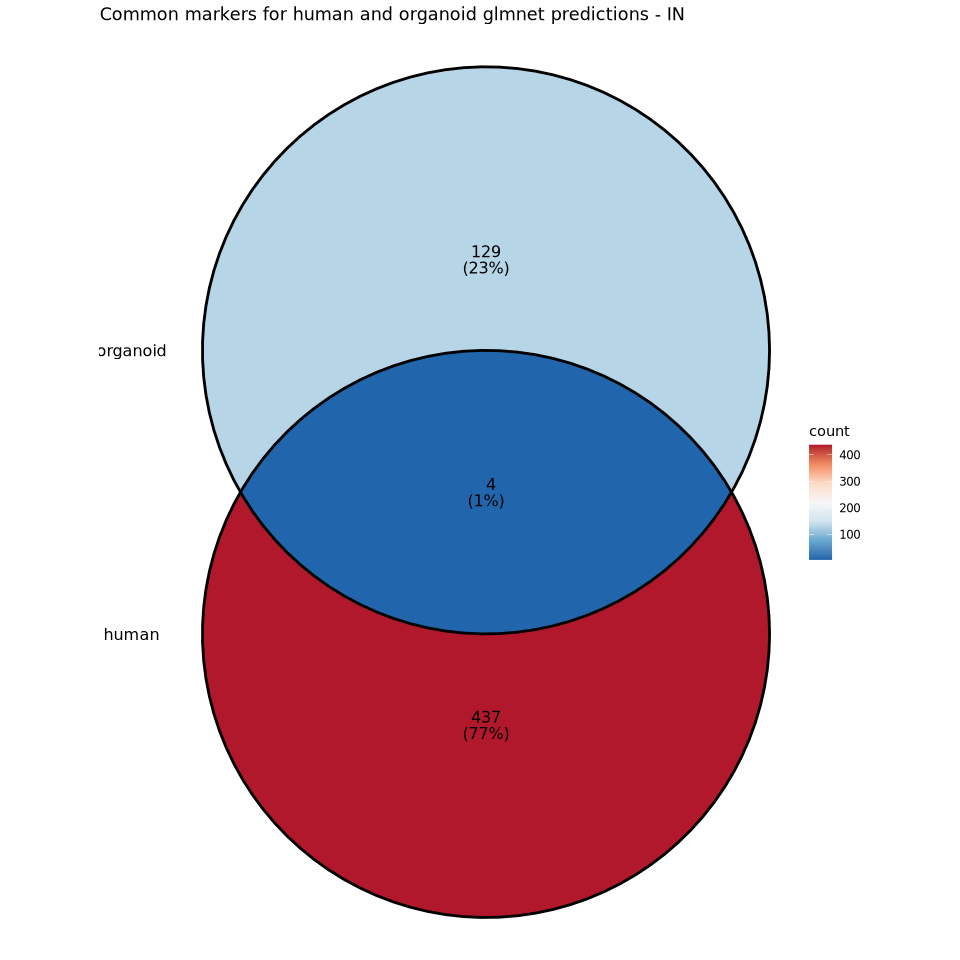

```r
common_glmnet_genes_IN = venn_common_glmnet_genes(
  human_coefs_path = file.path(params$human_glmnet_dir, "coefs_glmnet_human_Inhibitory_Neurons_leftOutPatients.txt"),
  organoid_coefs_path = file.path(params$organoid_glmnet_dir, "coefs_glmnet_organoids_COp1_10w_iN_acrossSeeds.txt"),
  threshold = N_nonZeroCoefs,
  title_label = "Common markers for human and organoid glmnet predictions - IN"
)
```

**EN**

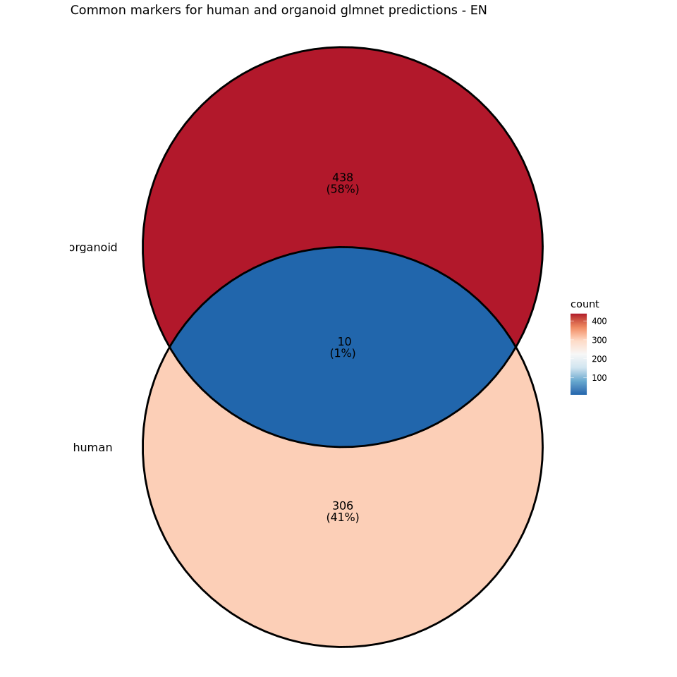

```r
common_glmnet_genes_EN = venn_common_glmnet_genes(
  human_coefs_path = file.path(params$human_glmnet_dir, "coefs_glmnet_human_Excitatory_Neurons_leftOutPatients.txt"),
  organoid_coefs_path = file.path(params$organoid_glmnet_dir, "coefs_glmnet_organoids_COp1_10w_exN_acrossSeeds.txt"),
  threshold = N_nonZeroCoefs,
  title_label = "Common markers for human and organoid glmnet predictions - EN"
)
```

**Note**

We used DESeq2 to perform DEA at the metacell (pseudobulk) level when all patients/organoid datasets are pooled together. Here we perform GSEA on genes which have > 0 log2FC | < 0 log2FC in both human and organoid datasets.

# Genes correlated log2FC

## IN

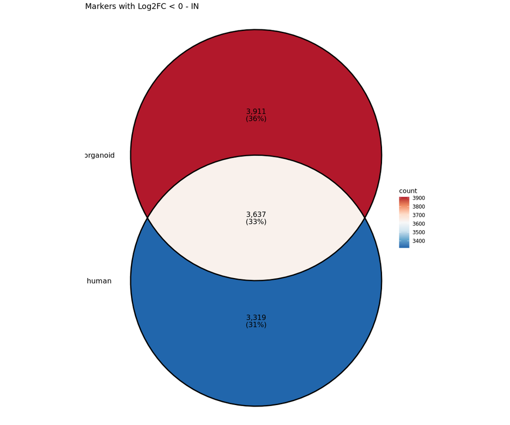

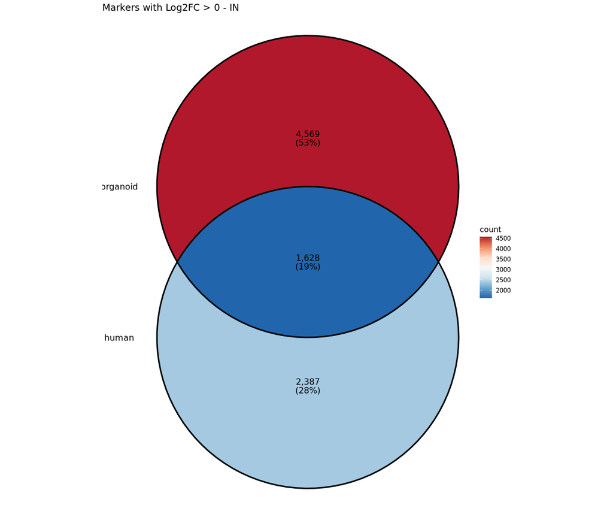

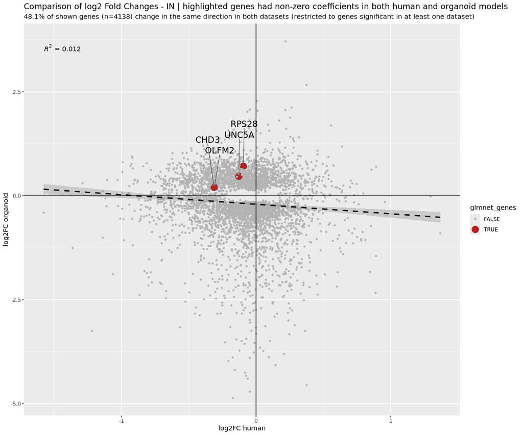

```r
merged_log2fc = plot_log2fc_concordance(
  human_dea_path = file.path(params$human_dea_dir, "DEA_metacell_iN_old_vs_young.csv"),
  organoid_dea_path = file.path(params$organoid_dea_dir, "DEA_metacell_ICE_vs_wt_iN_COp1_10w_organoids.csv"),
  common_glmnet_genes = common_glmnet_genes_IN,
  celltype_label = "IN"
)
```

## EN

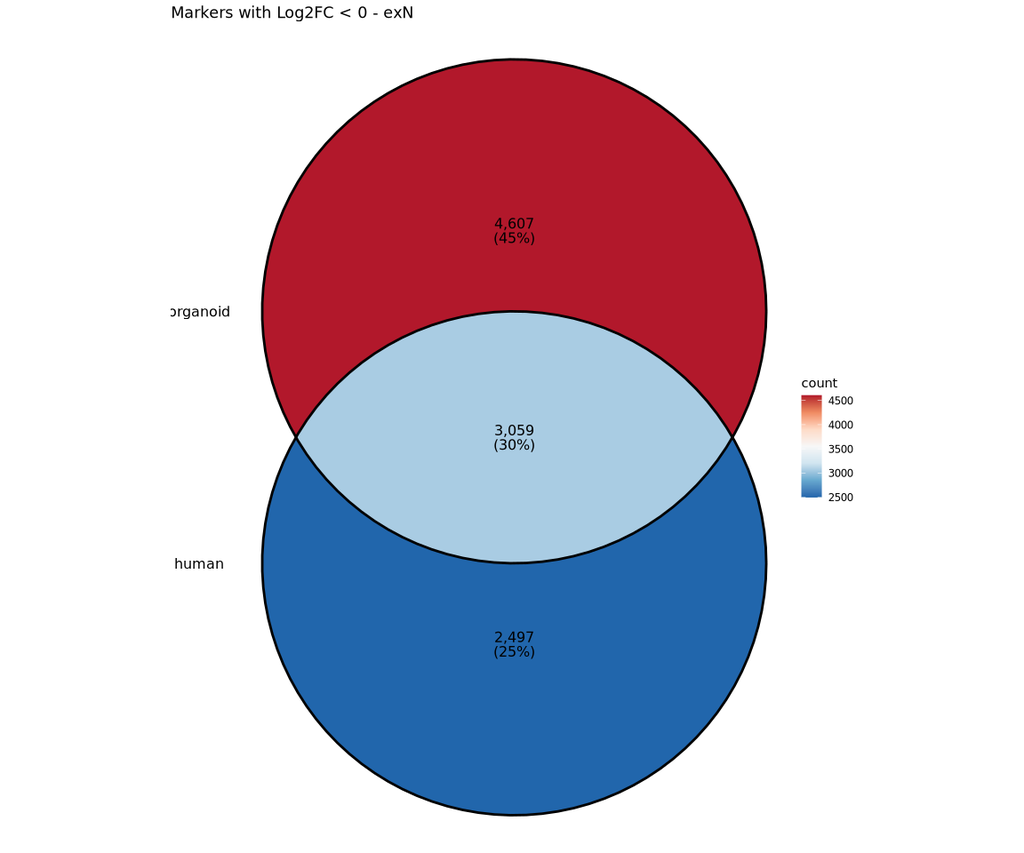

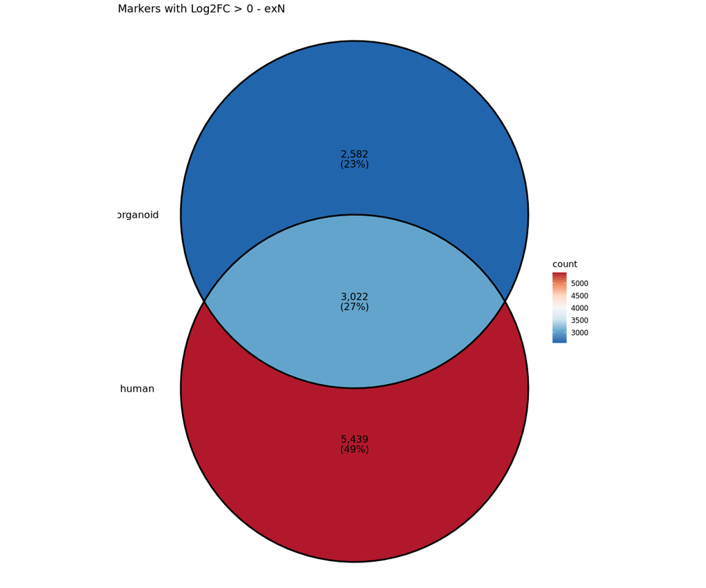

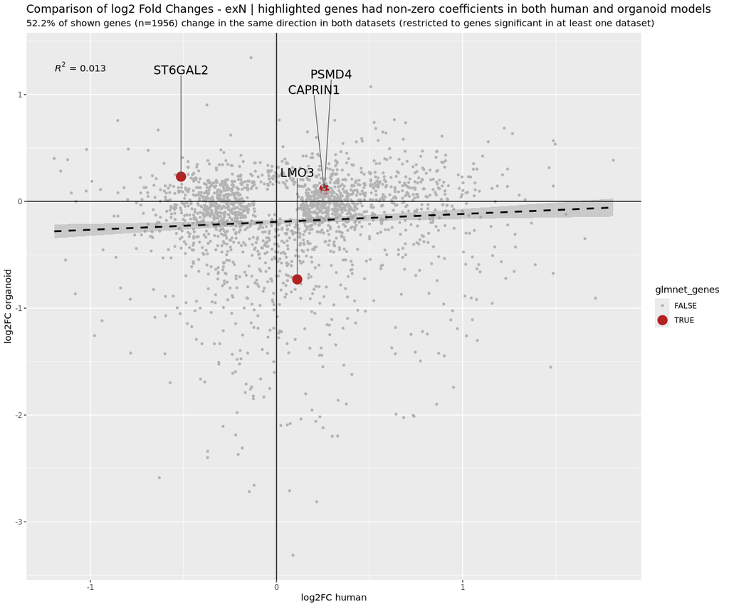

```r
merged_log2fc = plot_log2fc_concordance(
  human_dea_path = file.path(params$human_dea_dir, "DEA_metacell_exN_old_vs_young.csv"),
  organoid_dea_path = file.path(params$organoid_dea_dir, "DEA_metacell_ICE_vs_wt_exN_COp1_10w_organoids.csv"),
  common_glmnet_genes = common_glmnet_genes_EN,
  celltype_label = "exN"
)
```

## all neurons

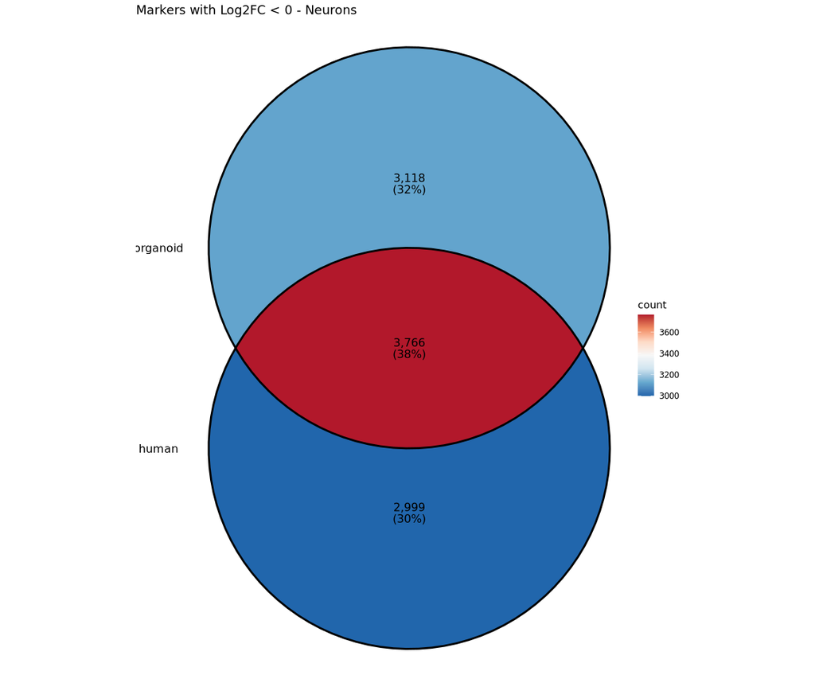

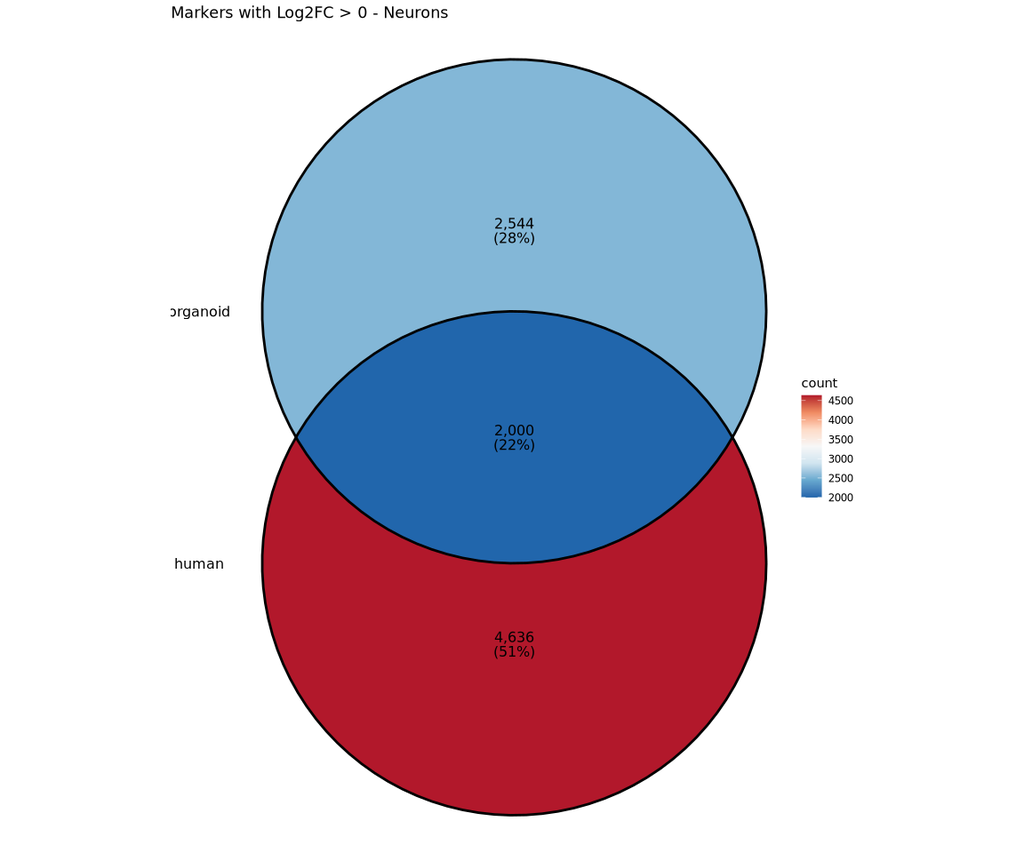

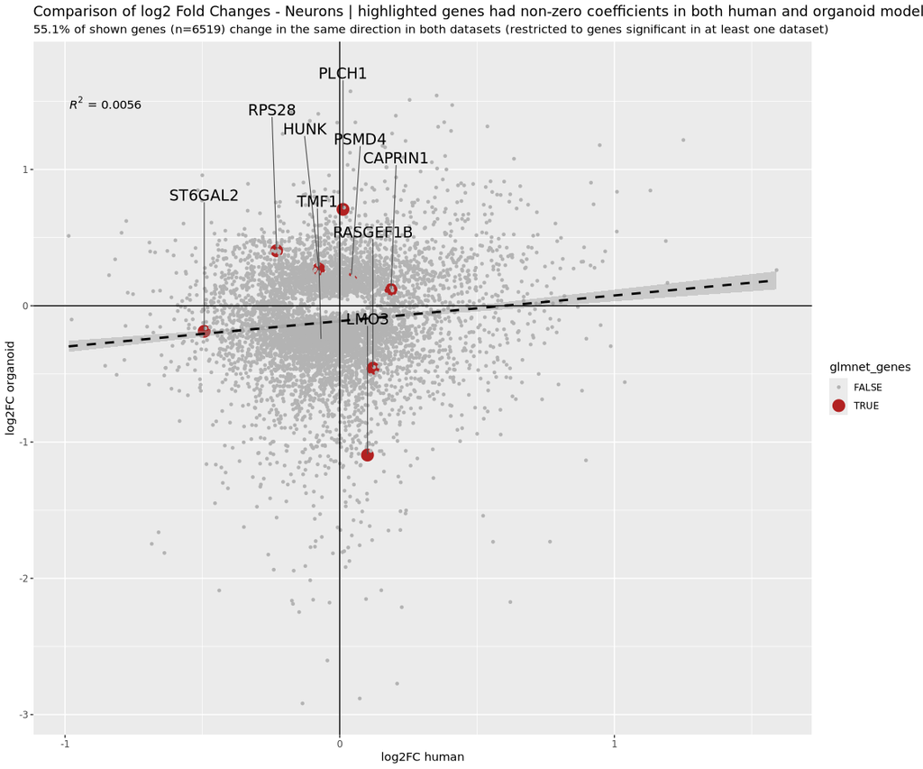

```r
merged_log2fc = plot_log2fc_concordance(
  human_dea_path = file.path(params$human_dea_dir, "DEA_metacell_neurons_old_vs_young.csv"),
  organoid_dea_path = file.path(params$organoid_dea_dir, "DEA_metacell_ICE_vs_wt_onlyneurons_allDatasets_organoids.csv"),
  common_glmnet_genes = c(common_glmnet_genes_EN,common_glmnet_genes_IN),
  celltype_label = "Neurons"
)
```

# Minimal gene set for organoid prediction

**Note**

Genes with positive/highest averaged_score are important to predict mCh while with negative/lowest score are important to predict wt. Model was built 20 times (20 seeds) with different train/test splits. When coefficient == 0, then this gene was not important for this seed’s model.

**CO 10w**

**IN**

```r
coefs_IN = read.table(file.path(params$organoid_glmnet_dir, "coefs_glmnet_organoids_COp1_10w_iN_acrossSeeds.txt"), row.names = 1)
# filter genes based on how many models their coefficient was != 0
rownames(coefs_IN) = coefs_IN$gene
coefs_IN = coefs_IN %>% select(-c(mean, gene))
coefs_IN = coefs_IN[rowSums(coefs_IN != 0) > N_nonZeroCoefs, ] %>%
  mutate(averaged_score = rowMeans(.)) %>%
  select(averaged_score, everything()) %>%
  round(2) %>%
  tibble::rownames_to_column("gene")

datatable(coefs_IN, options = list(pageLength = 25, autoWidth = TRUE), rownames = FALSE)
```

| gene | averaged_score | seed_1 | seed_2 | seed_3 | seed_4 | seed_5 | seed_6 | seed_7 | seed_8 | seed_9 | seed_10 | seed_11 | seed_12 | seed_13 | seed_14 | seed_15 | seed_16 | seed_17 | seed_18 | seed_19 | seed_20 |
| --- | --- | --- | --- | --- | --- | --- | --- | --- | --- | --- | --- | --- | --- | --- | --- | --- | --- | --- | --- | --- | --- |
| GRM5 | 0.11 | 0.09 | 0.07 | 0 | 0.16 | 0.06 | 0.13 | 0.13 | 0.19 | 0.16 | 0.11 | 0.16 | 0.13 | 0.12 | 0.09 | 0.1 | 0.13 | 0.08 | 0.17 | 0.11 | 0.09 |
| NKAIN2 | 0.07 | 0.05 | 0.1 | 0.08 | 0.09 | 0.08 | 0.05 | 0.09 | 0.07 | 0.07 | 0.04 | 0.08 | 0.11 | 0.09 | 0.06 | 0.05 | 0.06 | 0.07 | 0.02 | 0.02 | 0.05 |
| RPS21 | -0.17 | -0.14 | -0.14 | -0.05 | -0.17 | -0.14 | -0.19 | -0.19 | -0.23 | -0.2 | -0.22 | -0.16 | -0.24 | -0.19 | -0.22 | -0.18 | -0.14 | -0.19 | -0.12 | -0.24 | -0.1 |
| RALYL | 0.04 | 0 | 0.07 | 0.06 | 0.02 | 0.03 | 0.06 | 0.06 | 0.02 | 0.03 | 0.03 | 0.04 | 0 | 0.01 | 0.04 | 0.08 | 0 | 0.05 | 0.07 | 0.09 | 0.07 |
| PRKCB | 0.2 | 0.15 | 0.2 | 0.25 | 0.22 | 0.21 | 0.22 | 0.13 | 0.14 | 0.2 | 0.19 | 0.24 | 0.18 | 0.22 | 0.17 | 0.14 | 0.21 | 0.26 | 0.15 | 0.19 | 0.25 |
| RPL38 | -0.06 | -0.04 | -0.12 | 0 | 0 | -0.05 | -0.06 | -0.16 | -0.02 | 0 | -0.1 | -0.16 | 0 | -0.05 | -0.06 | 0 | -0.13 | -0.13 | -0.15 | 0 | 0 |
| LRP1B | 0.05 | 0.02 | 0.01 | 0.06 | 0.03 | 0.07 | 0.04 | 0.06 | 0.06 | 0.06 | 0.04 | 0 | 0.02 | 0.04 | 0.03 | 0.06 | 0.04 | 0.04 | 0.05 | 0.09 | 0.12 |
| RPS26 | -0.02 | -0.06 | -0.14 | 0 | 0 | 0 | 0 | -0.09 | -0.02 | 0 | 0 | 0 | 0 | 0 | -0.02 | -0.03 | -0.02 | 0 | -0.01 | 0 | 0 |
| RPS28 | -0.02 | -0.13 | 0 | 0 | 0 | -0.04 | -0.04 | -0.02 | 0 | -0.03 | 0 | -0.03 | 0 | 0 | -0.01 | -0.02 | -0.07 | -0.04 | -0.06 | 0 | 0 |
| PLXNA2 | -0.02 | -0.05 | 0 | 0 | 0 | -0.02 | -0.08 | -0.03 | 0 | 0 | -0.02 | -0.02 | -0.01 | 0 | -0.05 | -0.01 | -0.03 | -0.01 | -0.02 | 0 | 0 |

[output cut: 88 more lines]

**EN**

```r
coefs_EN = read.table(file.path(params$organoid_glmnet_dir, "coefs_glmnet_organoids_COp1_10w_exN_acrossSeeds.txt"))
rownames(coefs_EN) = coefs_EN$gene
coefs_EN = coefs_EN %>% select(-c(mean, gene))
coefs_EN = coefs_EN[rowSums(coefs_EN != 0) > N_nonZeroCoefs, ] %>%
  mutate(averaged_score = rowMeans(.)) %>%
  select(averaged_score, everything()) %>%
  round(2) %>%
  tibble::rownames_to_column("gene")

datatable(coefs_EN, options = list(pageLength = 25, autoWidth = TRUE), rownames = FALSE)
```

| gene | averaged_score | seed_1 | seed_2 | seed_3 | seed_4 | seed_5 | seed_6 | seed_7 | seed_8 | seed_9 | seed_10 | seed_11 | seed_12 | seed_13 | seed_14 | seed_15 | seed_16 | seed_17 | seed_18 | seed_19 | seed_20 |
| --- | --- | --- | --- | --- | --- | --- | --- | --- | --- | --- | --- | --- | --- | --- | --- | --- | --- | --- | --- | --- | --- |
| C12orf57 | -0.1 | -0.11 | -0.13 | -0.08 | -0.1 | -0.11 | -0.07 | -0.09 | -0.08 | -0.12 | -0.07 | -0.09 | -0.09 | -0.1 | -0.11 | -0.08 | -0.11 | -0.08 | -0.1 | -0.11 | -0.09 |
| CCND2 | -0.08 | -0.06 | -0.07 | -0.09 | -0.08 | -0.08 | -0.09 | -0.09 | -0.09 | -0.09 | -0.07 | -0.06 | -0.05 | -0.08 | -0.12 | -0.07 | -0.09 | -0.12 | -0.08 | -0.06 | -0.07 |
| DPY19L1 | -0.01 | -0.01 | -0.02 | -0.01 | -0.01 | -0.01 | -0.03 | -0.02 | 0 | -0.04 | 0 | -0.01 | -0.01 | -0.03 | -0.01 | 0 | -0.02 | -0.01 | -0.01 | 0 | 0 |
| H4C3 | -0.3 | -0.3 | -0.29 | -0.28 | -0.3 | -0.3 | -0.29 | -0.32 | -0.29 | -0.28 | -0.32 | -0.32 | -0.28 | -0.3 | -0.28 | -0.3 | -0.27 | -0.26 | -0.28 | -0.33 | -0.31 |
| UBL5 | -0.01 | 0 | 0 | -0.01 | 0 | 0 | -0.02 | 0 | -0.02 | -0.01 | -0.02 | -0.03 | -0.03 | -0.03 | -0.01 | -0.01 | -0.02 | 0 | -0.01 | 0 | 0 |
| SERF2 | -0.02 | -0.02 | -0.02 | -0.02 | -0.02 | -0.02 | 0 | 0 | -0.02 | -0.04 | 0 | 0 | -0.02 | 0 | -0.05 | 0 | -0.05 | -0.02 | -0.01 | -0.01 | -0.03 |
| NONO | -0.04 | -0.02 | 0 | -0.04 | -0.04 | -0.03 | -0.04 | -0.04 | -0.03 | -0.07 | -0.03 | -0.04 | -0.02 | -0.05 | -0.05 | -0.03 | -0.07 | -0.05 | -0.02 | -0.02 | -0.04 |
| CUX2 | -0.03 | -0.02 | -0.03 | -0.02 | -0.04 | -0.03 | -0.03 | -0.03 | -0.02 | -0.04 | -0.03 | -0.02 | -0.03 | -0.02 | -0.03 | -0.02 | -0.02 | -0.03 | -0.04 | -0.03 | -0.03 |
| NRG1 | 0 | 0 | -0.01 | 0 | 0 | 0 | -0.01 | 0 | 0 | 0 | 0 | 0 | 0 | 0 | -0.01 | 0 | -0.01 | -0.02 | 0 | 0 | 0 |
| ATP5ME | -0.04 | -0.02 | -0.03 | -0.06 | -0.03 | -0.03 | -0.04 | -0.05 | -0.04 | -0.06 | -0.03 | -0.03 | -0.05 | -0.06 | -0.04 | -0.02 | -0.04 | -0.08 | -0.01 | -0.06 | -0.04 |

[output cut: 336 more lines]

**CO 4m**

**IN**

```r
coefs_IN = read.table(file.path(params$organoid_glmnet_dir, "coefs_glmnet_organoids_COp1_4m_iN_acrossSeeds.txt"))
rownames(coefs_IN) = coefs_IN$gene
coefs_IN = coefs_IN %>% select(-c(mean, gene))
coefs_IN = coefs_IN[rowSums(coefs_IN != 0) > N_nonZeroCoefs, ] %>%
  mutate(averaged_score = rowMeans(.)) %>%
  select(averaged_score, everything()) %>%
  round(2) %>%
  tibble::rownames_to_column("gene")

datatable(coefs_IN, options = list(pageLength = 25, autoWidth = TRUE), rownames = FALSE)
```

| gene | averaged_score | seed_1 | seed_2 | seed_3 | seed_4 | seed_5 | seed_6 | seed_7 | seed_8 | seed_9 | seed_10 | seed_11 | seed_12 | seed_13 | seed_14 | seed_15 | seed_16 | seed_17 | seed_18 | seed_19 | seed_20 |
| --- | --- | --- | --- | --- | --- | --- | --- | --- | --- | --- | --- | --- | --- | --- | --- | --- | --- | --- | --- | --- | --- |
| GNG5 | -0.87 | -0.91 | -0.79 | -0.87 | -0.78 | -0.89 | -0.93 | -0.89 | -1.01 | -0.77 | -0.88 | -0.72 | -0.73 | -0.94 | -0.72 | -0.73 | -0.91 | -1.08 | -0.92 | -0.95 | -0.95 |
| TEAD2 | -0.12 | -0.2 | 0 | -0.19 | 0 | 0 | -0.27 | 0 | 0 | 0 | -0.04 | -0.19 | -0.3 | 0 | -0.28 | 0 | -0.31 | -0.47 | 0 | 0 | -0.09 |
| COL4A5 | -0.14 | -0.18 | 0 | -0.23 | -0.23 | -0.14 | -0.19 | -0.12 | -0.21 | -0.17 | -0.07 | -0.16 | -0.16 | -0.1 | -0.05 | -0.11 | -0.07 | -0.1 | -0.08 | -0.1 | -0.34 |
| NHLH1 | -0.23 | -0.3 | -0.01 | -0.29 | -0.31 | -0.07 | -0.31 | -0.21 | -0.17 | -0.36 | -0.4 | -0.35 | -0.27 | -0.32 | -0.35 | -0.26 | -0.23 | 0 | -0.16 | -0.06 | -0.23 |
| SLC6A16 | -0.2 | 0 | -0.06 | 0 | -0.44 | -0.62 | -0.15 | -0.29 | -0.03 | -0.12 | -0.02 | -0.25 | -0.72 | 0 | -0.26 | -0.22 | -0.17 | -0.15 | -0.34 | -0.07 | 0 |
| TMEM123 | -0.28 | -0.23 | -0.32 | -0.11 | -0.26 | -0.58 | -0.12 | -0.33 | -0.29 | -0.12 | -0.47 | -0.3 | -0.21 | -0.15 | -0.2 | -0.16 | -0.3 | -0.46 | -0.33 | -0.33 | -0.26 |
| METRN | -0.04 | 0 | -0.01 | -0.01 | -0.03 | 0 | -0.01 | -0.11 | 0 | -0.19 | 0 | -0.06 | 0 | -0.21 | 0 | -0.2 | -0.05 | 0 | 0 | 0 | 0 |
| ANK3 | 0.17 | 0.35 | 0.26 | 0.36 | 0.01 | 0.01 | 0.23 | 0.15 | 0.1 | 0.04 | 0.14 | 0.07 | 0.15 | 0.26 | 0.15 | 0.19 | 0.2 | 0.33 | 0.08 | 0.1 | 0.29 |
| PDLIM5 | -0.04 | 0 | 0 | 0 | 0 | 0 | 0 | -0.1 | -0.05 | -0.06 | 0 | -0.27 | -0.12 | 0 | 0 | -0.15 | -0.07 | 0 | -0.07 | 0 | 0 |
| ABCA1 | -0.11 | 0 | -0.21 | -0.12 | 0 | -0.18 | -0.27 | -0.22 | -0.18 | -0.02 | -0.06 | -0.26 | -0.11 | -0.17 | -0.1 | -0.02 | 0 | -0.03 | -0.18 | -0.15 | 0 |

[output cut: 27 more lines]

**EN**

```r
coefs_EN = read.table(file.path(params$organoid_glmnet_dir, "coefs_glmnet_organoids_COp1_4m_exN_acrossSeeds.txt"))
rownames(coefs_EN) = coefs_EN$gene
coefs_EN = coefs_EN %>% select(-c(mean, gene))
coefs_EN = coefs_EN[rowSums(coefs_EN != 0) > N_nonZeroCoefs, ] %>%
  mutate(averaged_score = rowMeans(.)) %>%
  select(averaged_score, everything()) %>%
  round(2) %>%
  tibble::rownames_to_column("gene")

datatable(coefs_EN, options = list(pageLength = 25, autoWidth = TRUE), rownames = FALSE)
```

| gene | averaged_score | seed_1 | seed_2 | seed_3 | seed_4 | seed_5 | seed_6 | seed_7 | seed_8 | seed_9 | seed_10 | seed_11 | seed_12 | seed_13 | seed_14 | seed_15 | seed_16 | seed_17 | seed_18 | seed_19 | seed_20 |
| --- | --- | --- | --- | --- | --- | --- | --- | --- | --- | --- | --- | --- | --- | --- | --- | --- | --- | --- | --- | --- | --- |
| PRDX1 | -0.17 | -0.11 | -0.17 | -0.3 | -0.24 | -0.13 | -0.19 | -0.15 | -0.18 | -0.2 | -0.08 | -0.12 | -0.14 | -0.2 | 0 | -0.12 | -0.15 | -0.26 | -0.23 | -0.21 | -0.27 |
| NFIA | -0.01 | 0 | 0 | -0.03 | 0 | 0 | 0 | -0.07 | 0 | 0 | 0 | -0.02 | -0.01 | -0.01 | 0 | 0 | 0 | 0 | 0 | 0 | -0.01 |
| PTPRK | -0.09 | -0.05 | -0.08 | -0.13 | -0.13 | -0.13 | -0.08 | -0.06 | -0.08 | -0.12 | -0.12 | -0.12 | -0.04 | -0.04 | -0.04 | -0.09 | -0.07 | -0.08 | -0.08 | -0.08 | -0.12 |
| PLCB1 | -0.02 | 0 | -0.01 | -0.01 | -0.01 | -0.02 | -0.04 | 0 | -0.03 | -0.02 | 0 | -0.08 | -0.02 | 0 | 0 | -0.01 | 0 | -0.04 | 0 | -0.05 | -0.03 |
| RBFOX1 | 0.02 | 0.07 | 0 | 0.04 | 0.01 | 0 | 0 | 0.01 | 0 | 0 | 0.01 | 0.02 | 0 | 0.05 | 0.01 | 0.02 | 0.02 | 0 | 0.01 | 0.05 | 0.08 |
| SLC27A4 | -0.38 | -0.45 | -0.38 | -0.35 | -0.38 | -0.4 | -0.38 | -0.39 | -0.32 | -0.41 | -0.37 | -0.32 | -0.36 | -0.32 | -0.46 | -0.45 | -0.39 | -0.35 | -0.39 | -0.36 | -0.4 |
| PGAP1 | -0.03 | -0.02 | -0.04 | -0.07 | 0 | 0 | -0.1 | -0.04 | -0.03 | 0 | 0 | 0 | -0.03 | -0.04 | -0.04 | -0.04 | -0.02 | -0.03 | -0.05 | -0.02 | 0 |
| SYNE2 | -0.02 | 0 | -0.02 | 0 | 0 | -0.06 | 0 | -0.01 | 0 | 0 | -0.07 | 0 | 0 | 0 | -0.11 | 0 | 0 | 0 | -0.03 | 0 | 0 |
| MYO6 | -0.1 | -0.11 | -0.13 | -0.11 | -0.07 | -0.05 | -0.12 | -0.11 | -0.02 | -0.06 | -0.15 | -0.12 | -0.19 | -0.1 | -0.11 | -0.13 | -0.05 | -0.13 | -0.11 | -0.06 | -0.14 |
| CECR2 | 0 | 0 | 0 | 0 | 0 | 0 | -0.01 | -0.01 | 0 | -0.01 | 0 | -0.02 | 0 | 0 | 0 | 0 | 0 | -0.01 | -0.02 | 0 | -0.01 |

[output cut: 94 more lines]

# Plot minimal predictive set

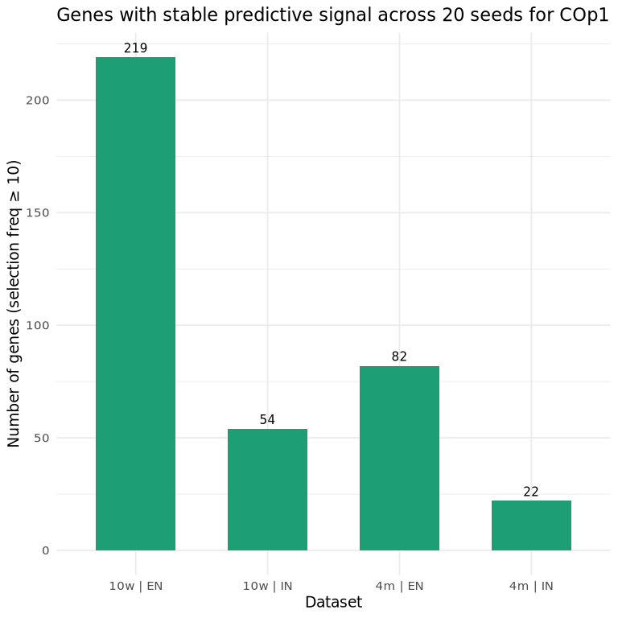

```r
library(dplyr)
library(ggplot2)

# 1. Read all four coefficient tables
coefs_CO1p_10w_IN = read.table(file.path(params$organoid_glmnet_dir, "coefs_glmnet_organoids_COp1_10w_iN_acrossSeeds.txt"))
coefs_CO1p_10w_EN = read.table(file.path(params$organoid_glmnet_dir, "coefs_glmnet_organoids_COp1_10w_exN_acrossSeeds.txt"))
coefs_CO1p_4m_IN  = read.table(file.path(params$organoid_glmnet_dir, "coefs_glmnet_organoids_COp1_4m_iN_acrossSeeds.txt"))
coefs_CO1p_4m_EN  = read.table(file.path(params$organoid_glmnet_dir, "coefs_glmnet_organoids_COp1_4m_exN_acrossSeeds.txt"))

# 2. Count predictive genes (selection_freq >= threshold) in one table
count_predictive_genes = function(coefs, threshold = 10) {
  coef_matrix = coefs %>% select(-gene, -mean)
  selection_freq = rowSums(coef_matrix != 0)
  sum(selection_freq >= threshold)
}

# 3. Build the comparison data frame
n_genes_df = data.frame(
  dataset = c("10w | IN", "10w | EN", "4m | IN", "4m | EN"),
  n_genes = c(
    count_predictive_genes(coefs_CO1p_10w_IN, threshold = 10),
    count_predictive_genes(coefs_CO1p_10w_EN, threshold = 10),
    count_predictive_genes(coefs_CO1p_4m_IN,  threshold = 10),
    count_predictive_genes(coefs_CO1p_4m_EN,  threshold = 10)
  )
)

# 4. Plot
ggplot(n_genes_df, aes(x = dataset, y = n_genes)) +
  geom_col(fill = "#1D9E75", width = 0.6) +
  geom_text(aes(label = n_genes), vjust = -0.5, size = 4) +
  labs(title = "Genes with stable predictive signal across 20 seeds for COp1",
       x = "Dataset", y = "Number of genes (selection freq \u2265 10)") +
  theme_minimal(base_size = 14)
```